# BI_retarining_datavis_hw_2

2025-09-27

```r
exams_translating <- c(
 "Defence against the dark arts exam" = "ЗОТИ",
 "Flying exam" = "Полеты",
 "Astronomy exam" = "Астрономия",
 "Herbology exam" = "Травология",
 "Divinations exam" = "Прорицания",
 "Charms exam" = "Заклинания",
 "History of magic exam" = "История магии",
 "Arithmancy exam" = "Нумерология",
 "Muggle studies exam" = "Магловедение",
 "Study of ancient runes exam" = "Древние руны",
 "Transfiguration exam" = "Трансфигурация",
 "Potions exam" = "Зельеварение",
 "Care of magical creatures exam" = "Уход за магическими существами"
)

hogwarts_houses_names <- c(
      "Gryffindor" = "Гриффиндор",
      "Hufflepuff" = "Пуффендуй",
      "Ravenclaw" = "Когтевран",
      "Slytherin" = "Слизерин"
    )

hogwarts_houses_colours <- c(
      "Gryffindor" = "#C50000",
      "Hufflepuff" = "#ECB939",
      "Ravenclaw" = "#41A6D9",
      "Slytherin" = "#1F5D25"
    )

hogwarts_houses_fill <- scale_fill_manual(
    name = "Факультет",
    labels = hogwarts_houses_names,
    values = hogwarts_houses_colours
  )

hogwarts_houses_colour <- scale_colour_manual(
    name = "Факультет",
    labels = hogwarts_houses_names,
    values = hogwarts_houses_colours
  )

hogwarts_houses_x <- scale_x_discrete(
    name = "Факультет",
    labels = hogwarts_houses_names
)
```

## 1 Изучите сайт со списком расширений ggplot2.Подберите ранее не использовавшийся в лекциях и домашних заданиях пакет, опции которого вам показались любопытными для визуализации данных hogwarts. Используйте возможности данного пакета, проинтерпретируйте получившийся график и опишите, почему использованный инструментарий пакета показался вам интересным и полезным.

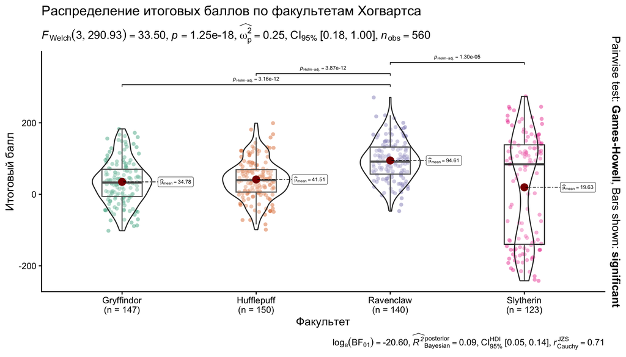

Распределение итоговых баллов по факультетам Хогвартса (ggstatsplot)

```r
ggbetweenstats(
  data = hogwarts,
  x = house,
  y = result,
  title = "Распределение итоговых баллов по факультетам Хогвартса",
  xlab = "Факультет",
  ylab = "Итоговый балл",
  pairwise.comparisons = TRUE,
  pairwise.display = "significant",
  centrality.plotting = TRUE,
  ggtheme = theme_classic(base_size = 18),
  messages = FALSE
)
```

Для визуализации данных выбран пакет ggstatsplot, который расширяет возможности ggplot2, автоматически выполняя статистический анализ и добавляя его результаты прямо на график. Такой подход позволяет объединить визуализацию распределений и вывод статистических критериев в одном информативном изображении, ято в ряде случаев может быть полезным, например для презентации результатов в PPT Построенный график с помощью функции ggbetweenstats() представляет собой комбинированную визуализацию, включающую элементы violin plot и boxplot. Кроме того, пакет ggstatsplot автоматически выполняет однофакторный дисперсионный анализ (ANOVA) и выводит p-значения для оценки статистической значимости различий между факультетами, в данном случае указаны лишь статистически значимые различия при попарном сравнении (чтобы не перегружать изображение). Представлены значения p в результате попарных сравнений (Games–Howell test), которые отображены над графиком. Апостериорный анализ показал, что средние значения итогового балла статистически значимо различались между факультетами Гриффиндор и Когтевран (р < 0.001), между Пуффендуй и Когтевран (р < 0.001), а также между факультетами Когтевран и Слизерин (р < 0.001). В тоже время, при попарном сравнении итогового балла между факультетами Гриффиндор и Пуффендуй, между Гриффиндор и Слизерин, а также между Пуффендуй и Слизерин статистически значимых раздичий обнаружено не было. Наконец, красная точка обозначает среднее значение, а горизонтальная линия медиану; расхождение между ними особенно заметное у факультета Слизерин отражает асимметрию распределения и большой разброс показателей, это видно и по boxplot и violin plot.

Таким образом, график одновременно демонстрирует распределение, статистические характеристики и индивидуальные данные, обеспечивая наглядное сравнение между факультетами.

## 2 Изучите информацию о графике treemap. Как вы полагаете, в чем его отличие от мозаик-плота? Исходя из структуры графика, предположите, в каких ситуациях лучше будет подходить treemap, а в каких – мозаик-плот. Создайте treemap на данных hogwarts. Вы вольны использовать любые ополнительные пакеты в этом задании.

Treemap показывает, из чего состоит выборка: каждый прямоугольник - это категория, а его площадь пропорциональна числу наблюдений. Прямоугольники можно вкладывать друг в друга, то есть легко показать иерархию «группа -> подгруппа». Mosaic - это «плитка» по двум категориям. Ширина и высота плиток отражают доли по каждой из переменных. Такой график удобен, когда нужно понять, есть ли связь между двумя признаками.

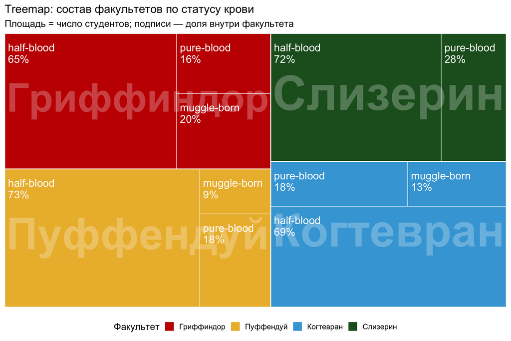

```r
library(treemapify)
library(grid)


# Подготовка данных
df_treemap <- hogwarts |>
  count(house, bloodStatus, name = "n") |>
  group_by(house) |>
  mutate(
    pct_in_house = n / sum(n),
    label = paste0(bloodStatus, "\n", scales::percent(pct_in_house, 1)),
    house_ru = hogwarts_houses_names[house]
  ) |>
  ungroup()

# График
ggplot(df_treemap, aes(area = n, fill = house, subgroup = house_ru, label = label)) +
  geom_treemap(colour = "white", size = 1) +
  geom_treemap_subgroup_border(colour = "white", size = 2) +
  geom_treemap_subgroup_text(
    label = df_treemap$house_ru,
    place = "centre", grow = TRUE, reflow = TRUE,
    colour = "white", alpha = 0.25, fontface = "bold", min.size = 18
  ) +
  geom_treemap_text(
    place = "topleft", grow = FALSE, reflow = TRUE, min.size = 7,
    colour = "white", padding.x = unit(2, "mm"), padding.y = unit(6, "mm")
  ) +
  scale_fill_manual(
    name = "Факультет",
    values = hogwarts_houses_colours,
    labels = hogwarts_houses_names
  ) +
  labs(
    title = "Treemap: состав факультетов по статусу крови",
    subtitle = "Площадь = число студентов; подписи — доля внутри факультета",
    x = NULL, y = NULL
  ) +
  theme_classic(base_size = 16) +
  theme(legend.position = "bottom")
```

## 3 Постройте “леденцовый график” (lollipop-plot) для количества набранных студентами 5-го курса баллов за весь учебный год (по оси ординат – id студента, по оси абсцисс – итоговый балл). Отсортируйте студентов в порядке убывания итогового балла. Раскрасьте точки на “леденцах” в зависимости от сердцевины волшебной палочки. Палочки с сердечной жилой дракона должны быть красного цвета, с пером феникса – желтого, с волосом единорога – серого.В этом задании вы можете использовать только основные пакеты tidyverse.

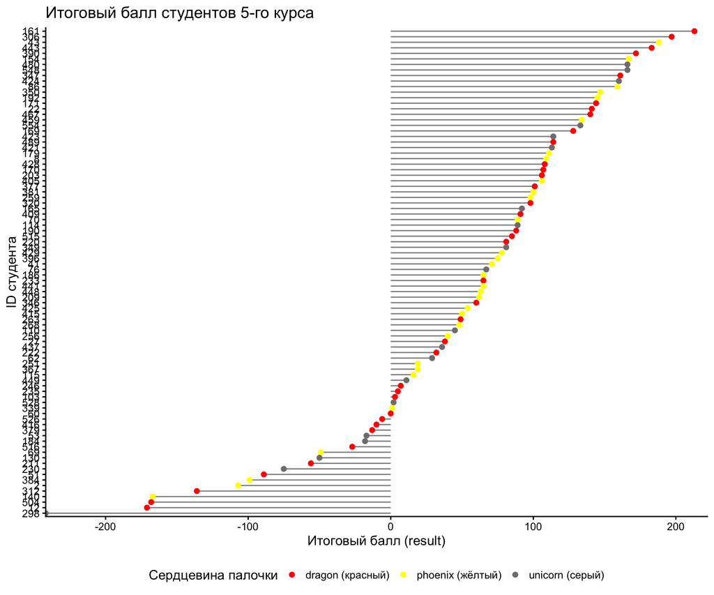

```r
# палитра для сердцевин палочек
wand_cols <- c(
  "dragon heartstring" = "red",
  "phoenix feather"    = "yellow",
  "unicorn hair"       = "grey50"
)

lolli_df <- hogwarts %>%
  filter(course == 5) %>%                #  5-й курс
  select(id, result, wandCore) %>%
  drop_na(result, wandCore) %>%
  arrange(desc(result)) %>%              # сортировка по убыванию балла
  mutate(
    id = factor(id, levels = id),        # порядок по оси Y согласно сортировке
    id = fct_rev(id)                     # чтобы лучший был сверху
  )

ggplot(lolli_df, aes(x = result, y = id)) +
  geom_segment(aes(x = 0, xend = result, y = id, yend = id), linewidth = 0.7, alpha = 0.5) +
  geom_point(aes(color = wandCore), size = 2.4) +
  scale_color_manual(values = wand_cols, name = "Сердцевина палочки",
                     breaks = c("dragon heartstring","phoenix feather","unicorn hair"),
                     labels = c("dragon heartstring" = "dragon (красный)",
                                "phoenix feather"    = "phoenix (жёлтый)",
                                "unicorn hair"       = "unicorn (серый)")) +
  labs(title = "Итоговый балл студентов 5-го курса",
       x = "Итоговый балл (result)", y = "ID студента") +
  theme_classic(base_size = 16) +
  theme(legend.position = "bottom") +
  scale_x_continuous(expand = expansion(mult = c(0, 0.02)))
```

## 4

Положительных сторон данного графика я не вижу совсем (у меня частичный дальтонизм)), и для меня вообще (да и наверное для многих) очень плохо не видны представленные данные Итак, что в первую очередь мешает при взляде на график это основая фоновая картинка медведя + полупрозрачные слои, линии в виде сетки, что создает сильный визуальный шум и ухудшает читаемость.

Хотя указывается что максимальный балл 2, по оси Y не понятно в каких единицах представлены данные и еще подписано “ms”. Вероятно представлены bar plot (с данными ДИ, СО или SE, какие границы, не ясно по данному графику). По оси Х полагаю недели, однако во первых они представлены не по возрастанию 14, 11, 8, 18, 27, 36, что не дает делать такие выводы как в задаче, что “В последующие недели балл достоверно снижался, достигая минимальных значений к концу года”. Кпроме того, избегаем использование термина “достоверность”. В зачаче написано с начала года до конца года, соответсвенно отображение должно начинаться с нуля, далее 1 неделя и тд., и в конца последняя неделя года, соответсвенно 52я неделя, если учесть каинкулы то 40я неделя. Еще по оси Х необходимо указывать единый интервал, например каждые 4 недели.

Таким образом, делать выводы о снижении среднего балла в динакмике по представленному рисунку мы не можем.

Кроме того, авторвми сделан вывод что данный процесс связан с ухудшением психологического состояния преподавателей означенного учебного заведения. По данному рисунку вообще никаких предположений о причине динамики баллов мы не можем, не важно правильно был он составлен или нет. Чтобы выявить ассоциацию динамики баллов с определенными факторами необходимо использовать другие меры ассоциации - возможно линейную регрессию/смешанные линейные модели.

В любом случае, по данному графику никаких предположений о причине динамики баллов мы не можем, тем более заменять преподавателей и объявлять выговор с занесением в личное дело.

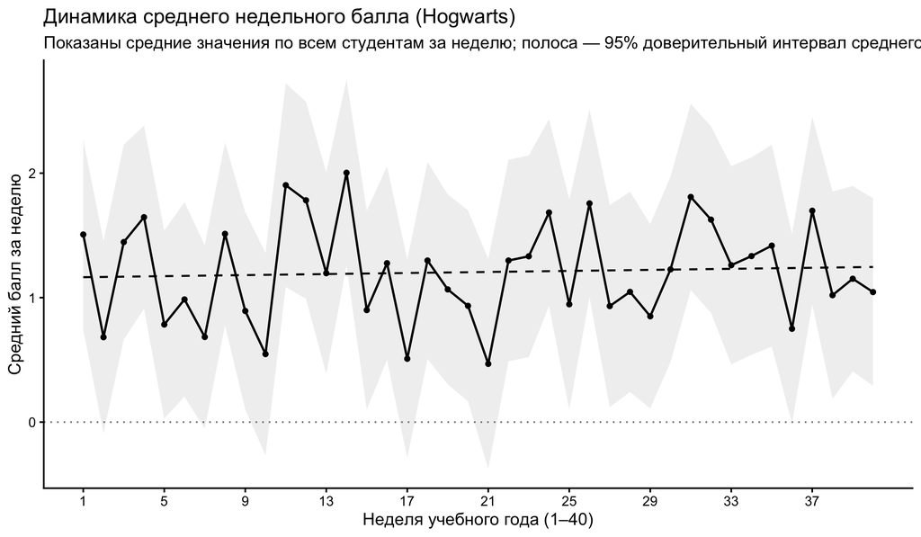

```r
# 1) поготовка данных
weekly_long <- hogwarts %>%
  pivot_longer(cols = matches("^week_\\d+$"),
               names_to = "week", values_to = "score") %>%
  mutate(week = readr::parse_number(week)) %>%
  filter(!is.na(score) & !is.na(week))


weekly_sum <- weekly_long %>%
  group_by(week) %>%
  summarise(
    n    = sum(!is.na(score)),
    mean = mean(score, na.rm = TRUE),
    se   = sd(score, na.rm = TRUE) / sqrt(n),
    lwr  = mean - 1.96 * se,
    upr  = mean + 1.96 * se,
    .groups = "drop"
  )

# 2) график
ggplot(weekly_sum, aes(x = week, y = mean)) +
  geom_ribbon(aes(ymin = lwr, ymax = upr), alpha = 0.20, fill = "grey70") +
  geom_line(linewidth = 1.0, color = "black") +
  geom_point(size = 1.8, color = "black") +
  geom_smooth(method = "lm", se = FALSE, linetype = "dashed", linewidth = 0.9, color = "black") +
  geom_hline(yintercept = 0, linetype = "dotted", color = "grey50") +
  scale_x_continuous(breaks = seq(1, 40, by = 4)) +
  labs(
    title = "Динамика среднего недельного балла (Hogwarts)",
    subtitle = "Показаны средние значения по всем студентам за неделю; полоса — 95% доверительный интервал среднего",
    x = "Неделя учебного года (1–40)",
    y = "Средний балл за неделю"
  ) +
  theme_classic(base_size = 16)
```

## 5 Рубрика “вредные советы” А теперь воспроизведите график из задания выше. Подсказка к реализации элемента, который мы не упоминали на лекции, находится в датасете podskazka2.csv – сделайте из него скаттерплот, отрисовав переменную X по горизонтали, а Y – по вертикали. Уточнение – не обязательно точно попасть в конкретный цвет. Задание не предполагает угадывание оттенков “на глаз”

```r
podskazka2 <- read_csv("data/podskazka2.csv")
```

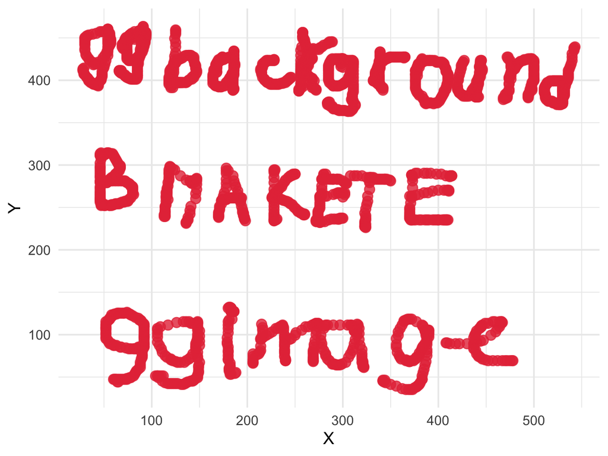

```r
ggplot(podskazka2, aes(x = X, y = Y)) +
  geom_point(size = 4, alpha = 0.8, color = "#E63946") +
  theme_minimal(base_size = 16)
```

[figure not shown]

```r
library(ggimage)
library(grid)

#  данные
weekly_sum <- tibble(
  week = factor(c(14, 11, 8, 18, 27, 36), levels = c(14, 11, 8, 18, 27, 36)),
  ms   = c(205, 125, 82, -45, -122, -188)
)

# диапазон
y_lims <- c(-200, 250)
y_breaks <- seq(-200, 250, 10)

bands <- tibble(
  xmin = c(0.5, 1.5, 2.5, 3.5, 4.5, 5.5),
  xmax = c(1.5, 2.5, 3.5, 4.5, 5.5, 6.5),
  fill = c("#60E37E", "#A4FF72", "#FFE06B", "#FFA07A", "#FF6F6B", "#E63C3C")
)

#  цвета столбиков
bar_cols <- c("#2B3D2B","#2E3F2E","#2F3133","#303337","#2E2E2E","#1A1A1A")

#  усы для столбиков
err_df <- weekly_sum %>%
  mutate(ymin = ms - 14, ymax = ms + 14)

#  диагональные стрелки
diag_df <- tibble(
  x = c(1, 1),
  y = c(230, 230),
  xend = c(6, 6),
  yend = c(-190, -190),
  col = c("red"),
  lwd = c(1.4, 0.9)
)

#  графика
p <- ggplot() +
  # вертикальные зоны
  geom_rect(data = bands,
            aes(xmin = xmin, xmax = xmax, ymin = y_lims[1], ymax = y_lims[2], fill = fill),
            alpha = 0.22) +
  scale_fill_identity() +

  # столбики
  geom_rect(
    data = weekly_sum,
    aes(xmin = as.numeric(week) - 0.20,
        xmax = as.numeric(week) + 0.20,
        ymin = -200,
        ymax = ms),
    fill = bar_cols, alpha = 0.7
  ) +

  # усы
  geom_errorbar(data = err_df,
                aes(x = week, ymin = ymin, ymax = ymax),
                width = 0.12, color = "black", linewidth = 2) +

  # диагональные стрелки
  geom_segment(data = diag_df,
               aes(x = x, y = y, xend = xend, yend = yend),
               color = diag_df$col, linewidth = diag_df$lwd,
               arrow = arrow(length = unit(5, "pt"))) +

  # плашки
  geom_label(aes(x = 1.25, y = 225,
                 label = "В начале учебного года педагоги\nрасположены мотивировать учащихся"),
             fill = "white", color = "darkgreen", label.size = 0, size = 3.8) +
  geom_label(aes(x = 5.4, y = -155,
                 label = "К концу года учителя применяют\nбольше репрессивных мер"),
             fill = "white", color = "red", label.size = 0, size = 3.8) +

  # оформление
  scale_x_discrete(name = "Week number") +
  scale_y_continuous(name = "ms", limits = y_lims, expand = c(0, 0)) +
  labs(
    title = "Эмоциональное выгорание преподавателей или лень учеников?",
    subtitle = "Semantical decreasing of mean score for every subsequent week in Hogwarts"
  ) +
  theme_bw(base_size = 12) +
  theme(panel.grid = element_blank()) +
  annotate("text", x = 0.7, y = -190, label = "ms",
           angle = 90, hjust = 0, size = 3.2)
#  фон
ggbackground(p, background = "images/fire_bear_2.png")
```

## 6

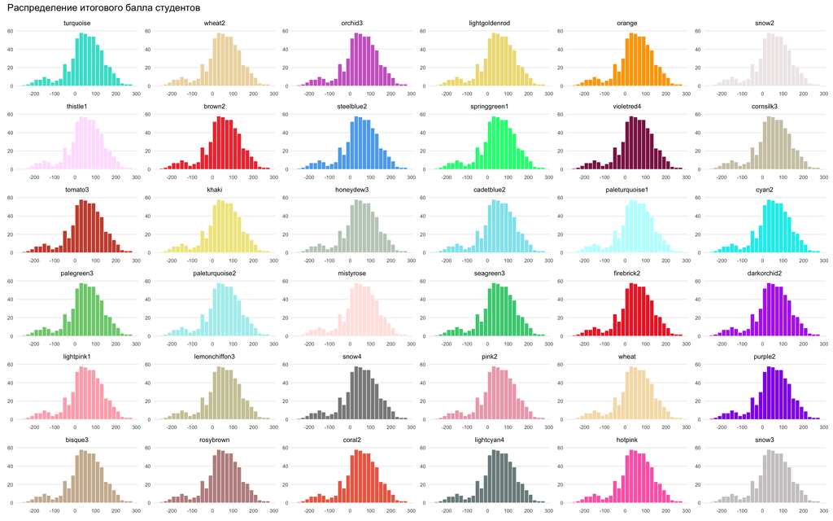

```r
set.seed(2025)

colours_ <- colours()
res_colours <- colours_[colours_ |> str_detect("grey|gray|black|white", negate = TRUE)]|>
  sample(size = 36)
library(patchwork)

# функция для построения одной гистограммы по цвету

hist_result <- function(colour) {
  ggplot(hogwarts, aes(x = result)) +
    geom_histogram(
      binwidth = 20,
      fill = colour,
      color = "white",
      linewidth = 0.3,
      boundary = 0
    ) +
    labs(title = colour, x = NULL, y = NULL) +
    theme_minimal(base_size = 10) +
    theme(
      plot.title = element_text(hjust = 0.5, size = 9),
      axis.text = element_text(size = 7),
      panel.grid.minor = element_blank(),
      panel.grid.major.x = element_blank()
    )
}

# создаем список графиков по всем 36 цветам

plots <- purrr::map(res_colours, hist_result)

# собираем все графики в одно полотно

wrap_plots(plots, ncol = 6) +
  plot_annotation(title = "Распределение итогового балла студентов")
```